# COVID-19 in Newfoundland and Labrador

Amy Hurford and Zahra Mohammadi

[Memorial University of Newfoundland and Labrador,](https://www.mun.ca/math/) [University of Guelph,](https://mathstat.uoguelph.ca/) [Canadian Network for Modelling Infectious Disease,](https://canmod.net/) [Mathematics for Public Health,](http://www.fields.utoronto.ca/activities/public-health) [One Health Modelling Network for Emerging Infections](https://www.yorku.ca/science/cdm/2021/04/09/ccdm-network-to-model-emerging-infectious-diseases-receives-2-5-million-in-federal-funding/)

This website visualizes:

- Regional COVID-19 cases reported by [Newfoundland and Labrador (NL)](https://www.gov.nl.ca/releases/covid-19-news/),
- Regional COVID-19 cases per 100,000 people in a NL Regional Health Authority,

and reports:

- the doubling time of reported cases.

The data begins on December 15, 2021 when the first Omicron case was reported in NL. Our presentation of these data by region suggests substantial infection spread within health regions, but limited spread between regions.

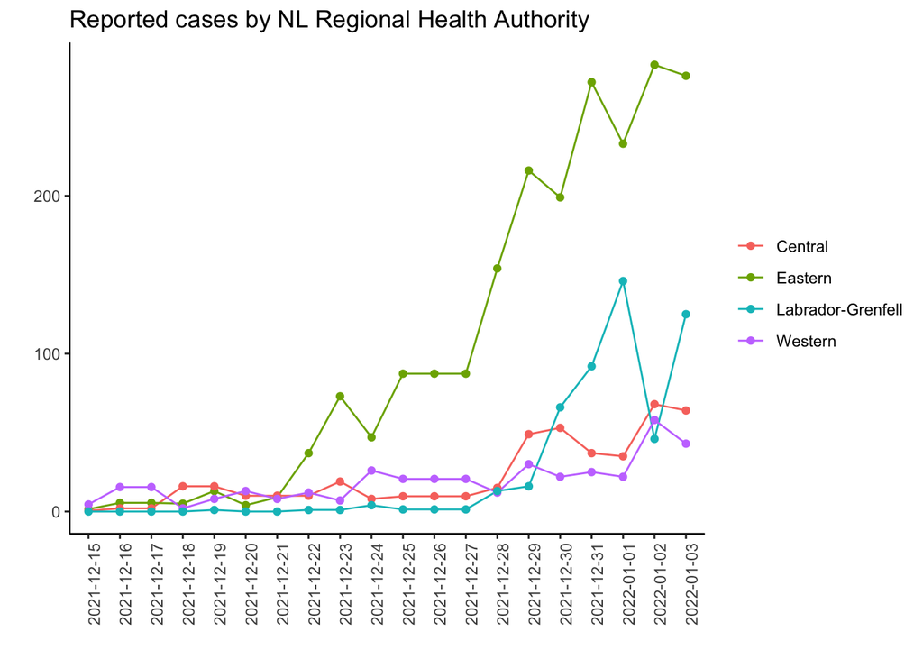

**Doubling times**

The doubling time is the days until the number of reported cases doubles (assuming exponential growth). Our doubling time calculations consider the number of reported cases over the last 10 days with 95% confidence intervals in parenthesis.

Eastern Health: 5.66 days [3.98, 9.15]

Central Health: 9.86 days [6.65, 18.33]

Western Health: 22.03 days [11.74, 158.17]

Labrador-Grenfell Health: 4.14 days [2.44, 9.09]

When no upper limit appears for the 95% confidence interval this is because exponential decay is implied. Fitting is performed using nonlinear least squares.

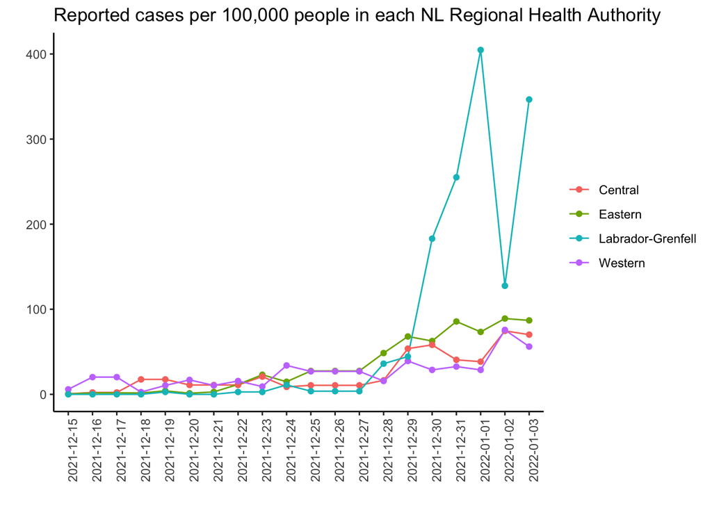